# Untitled

roger

10/17/2016

## Fitting a negative binomial with unknown $r$ and $p$.

```r
alpha = trueR = 3; ## Try 3, 30 and 300.
N = 1000
mu = 30
beta = mu/alpha
trueP = 1/(beta+1)
data1 = rnbinom(N, size=alpha, prob=trueP)
```

Alternatively, two stage sampling:

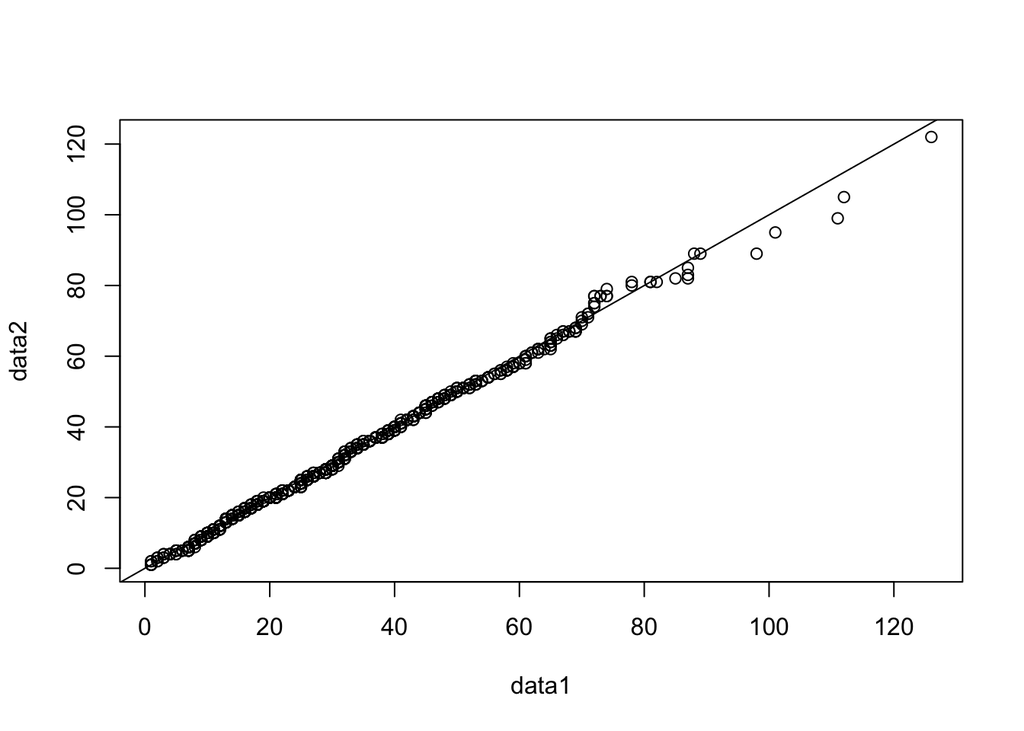

```r
theGammas = rgamma(N, shape=alpha, scale=1/trueP - 1)
data = data2 = rpois(N, theGammas)
qqplot(data1, data2)
abline(a=0,b=1)
```

So we can see that the composition method gives the same distribution, negative binomial.

### Empirical Bayes: “empirical step” using conditional maximization.

We can get reasonable starting values by fitting the mean and data variance .

```r
pHatStart = dataMean/dataVar
rHatStart = dataMean*pHatStart/(1-pHatStart)
pHatStart = pHatStart/10
rHatStart = rHatStart * 10
```

Now let’s iterate, starting with $pHat$ = 0.01 and $rHat$ = 30.3. (Compare with the true values 0.0909091 and 3.) We’ll see if we can recover the parameters.

```r
nIters = 1000
rHatVec = rep(NA, nIters)
rHatVec[1] = rHatStart
pHatVec = rep(NA, nIters)
pHatVec[1] = pHatStart
for(iter in 2:nIters) {
  rHat = rHatVec[iter-1]
  pHat = N*rHat/(N*rHat+sum(data))
  ## Or, 1/(1+mean(data)/rHat)
  searchInterval = rHat*c(1/10, 10)
  rHat= uniroot(f=function(r)
        sum(digamma(data+r)) - N*digamma(r) + N * log(pHat),
        interval=searchInterval)$root
  pHatVec[iter] = pHat;  rHatVec[iter]=rHat
}
cat(trueP, " ", trueR, "\n")
```

```
## 0.09090909   3
```

```r
cat(pHatVec[nIters], " ", rHatVec[nIters], "\n")
```

```
## 0.08973424   2.922806
```

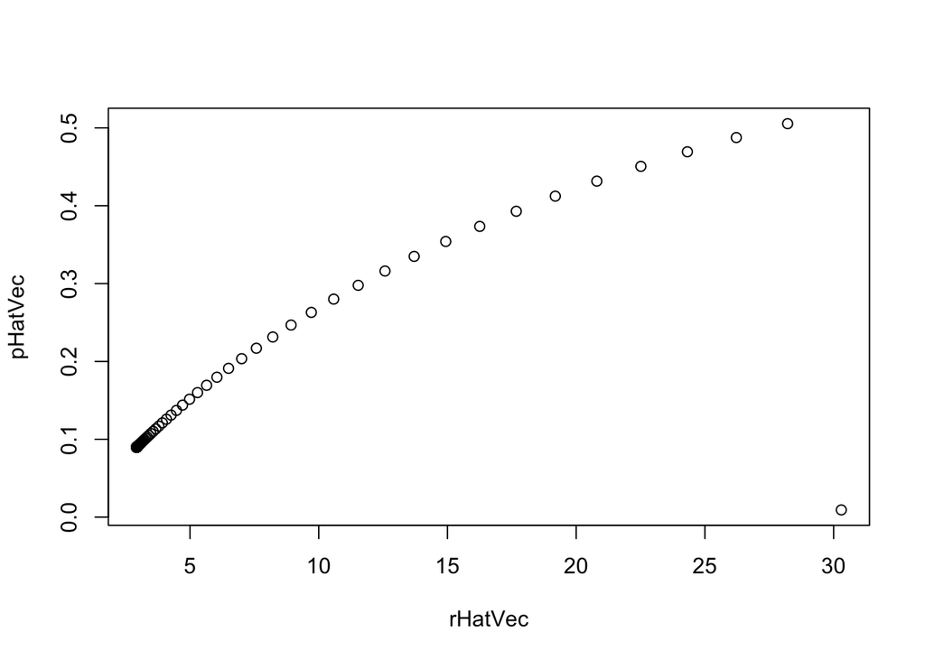

```r
plot(rHatVec, pHatVec)
```

```r
pHat = pHatCM = pHatVec[nIters]
rHat = rHatCM = rHatVec[nIters]
```

This is the “Empirical” step of Empirical Bayes.

We can compare this maximum likelihood estimate to the Poisson fit, obtained by matching the mean $r*(1-p)/p$ = 29.649:

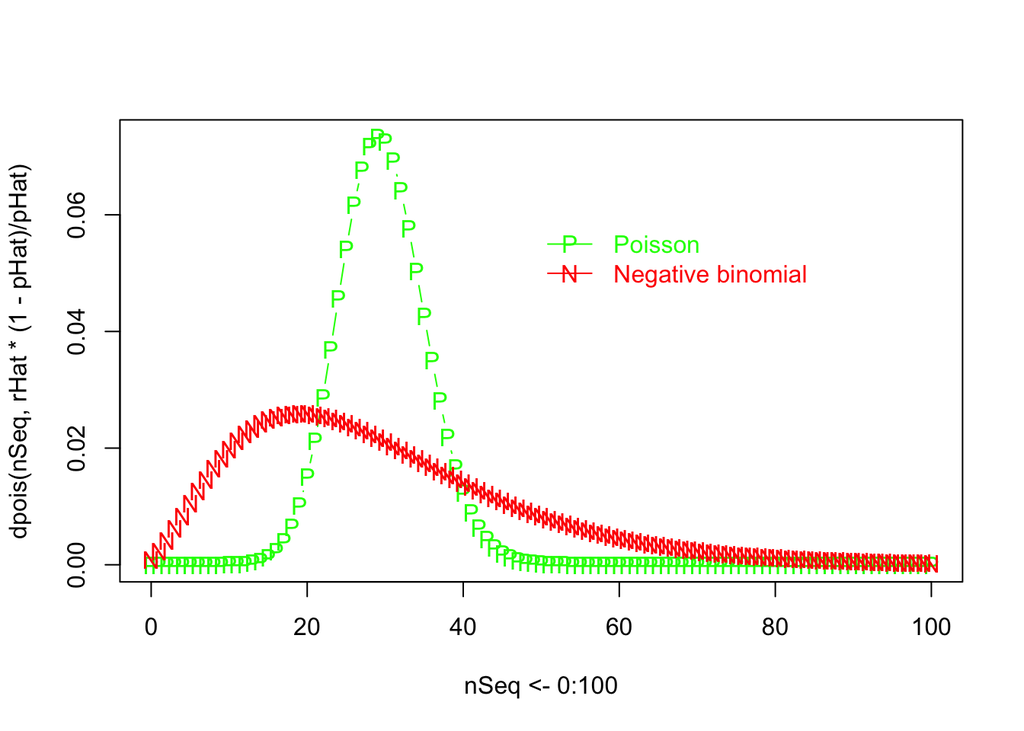

```r
plot(nSeq <- 0:100, dpois(nSeq, rHat*(1-pHat)/pHat), pch="P",
col="green", type="b")
points(nSeq, dnbinom(nSeq, size=rHat, prob=pHat), pch="N",
  col="red", type="b")
legend(x=50, y=0.06, box.col=NA,
  legend=c("Poisson","Negative binomial"),
  pch=c("P","N"), text.col=c("green", "red"),
  lty=c(1,1), col=c("green", "red"))
```

### Empirical Bayes: Bayes step

The Bayes step consists of estimating poisson means for each observation:

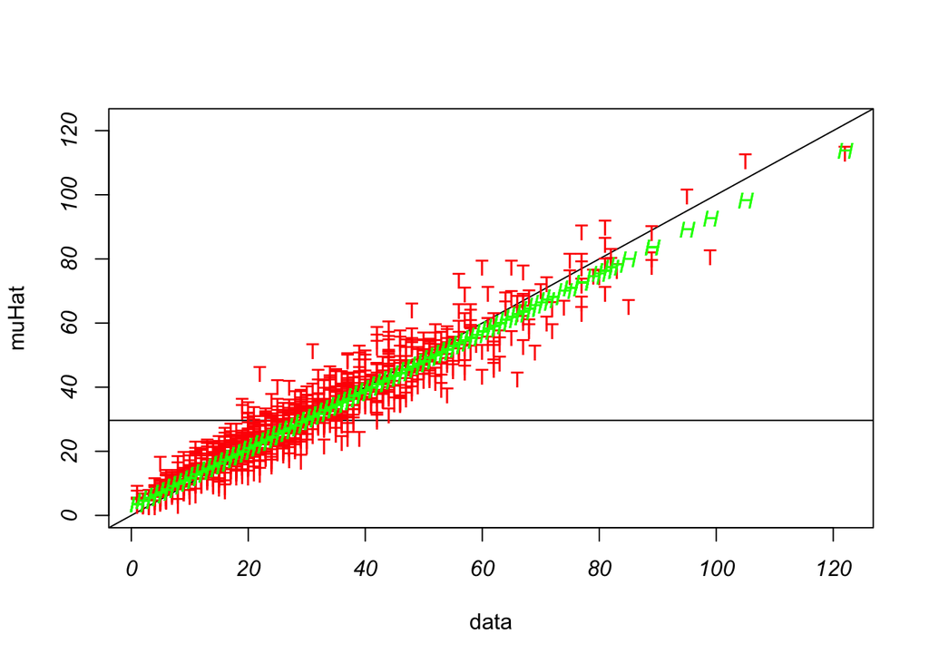

```r
muHat = (data+rHat)*(1-pHat)
plot(data, muHat, ylim=range(data), pch="H", font=3, col='green')
abline(a=0,b=1)
abline(h=rHat*(1-pHat)/pHat)  ## Marginal mean.
points(data, theGammas, col='red', pch='T')
points(data, muHat, pch="H", font=3, col='green')
```

We see the “shrinking” from the raw data estimate towards the grand mean, sacrificing unbiasedness for variance reduction. If $hat(r)$ is small, say 3, then the “prior” is very broad, and the information is primarily from the data. There is little shrinking. But if $hat(r)$ is big, like 30, the shrinking is fairly strong.

How do the estimated gammas compare with the true gammas?

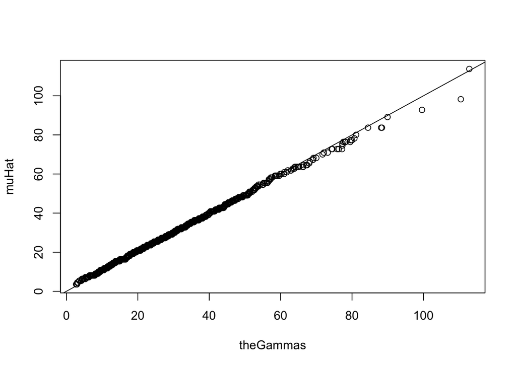

```r
qqplot(theGammas, muHat)
abline(a=0,b=1)
```

This is a little tilted– unknown whether due to the skewness of the Poisson or of the gamma, or just a bug.

### EM algorithm approach

Now let’s try it the EM way. The derivatives of $Q$ are:

$$\begin{gathered}
0 = \frac{{\partial Q}}{{\partial \alpha }} = - n\psi (\alpha ) - n\log \beta + {T_1}^* \\
0 = \frac{{\partial Q}}{{\partial \beta }} = - n\alpha /\beta - {T_2}^*/{\beta ^2}\quad \\
\end{gathered}$$

and setting them equal to zero, we get the following loop:

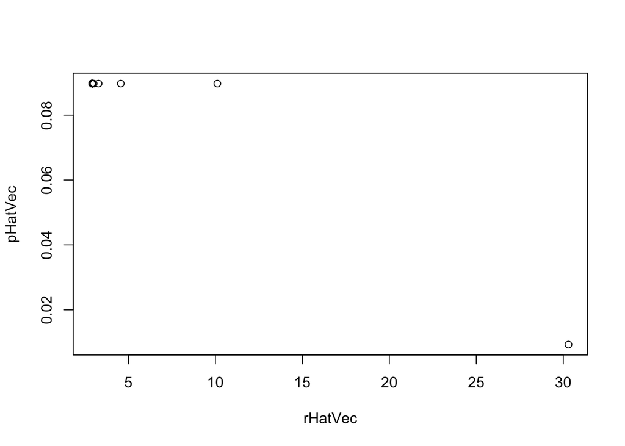

```r
nIters = 1000
rHatVec = rep(NA, nIters)
rHatVec[1] = rHatStart
pHatVec = rep(NA, nIters)
pHatVec[1] = pHatStart
for(iter in 2:nIters) {
  alphaStar = rHatVec[iter-1]
  alpha_I_Star = data + alphaStar
  betaStar = 1 - pHatVec[iter-1]
  T1star = sum(digamma(alpha_I_Star) +
            log(betaStar) )
  T2star = sum(data + alphaStar) * betaStar
  searchFunction = function(betaTemp) {
    alphaTemp = (T2star/betaTemp/N)
    return(-N*digamma(alphaTemp)-N*log(betaTemp)+T1star)
  }
  searchInterval = betaStar*c(1/100, 100)
  searchResult = uniroot(f=searchFunction,
    interval=searchInterval)
  betaHat = searchResult$root
  alphaHat = T2star/betaHat/N

  pHatVec[iter] = pHat;  rHatVec[iter] = alphaHat
}
pHatEM = pHatVec[iter]
rHatEM = rHatVec[iter]
plot(rHatVec, pHatVec)
```

Comparing the truth to the two final estimates after 1000 iterations:

```r
results = data.frame(truth=c(trueR, trueP),
                     CM=c(rHatCM, pHatCM),
                EM=c(rHatEM, pHatEM) )
dimnames(results)[[1]] = c("R", "P")
results
```

```
##        truth         CM         EM
## R 3.00000000 2.92280644 2.92280662
## P 0.09090909 0.08973424 0.08973424
```